# psy4802_finalProjectAnalysis

Brady M. Chisholm

2024-11-25

## Overview

In this pupil dilation data, measurements are one subjects average under specific combinations of conditions (4 SNR conditions, 5 quintiles), averaged over the 7-9 seconds time stamp in a trial.

This results in 20 measurements per subject. For example, the first subject in this data set is P02, occupying the first 20 rows, followed by P03, etc.

This analysis serves as an initial exploration. Ideally, the data should include trial-by-trial measurements (not averages), which would significantly increase temporal resolution and the quality of our statistics.

Future analyses will extend from this project using raw data instead of the averages, and depending on results, a different model too.

### Load data, prep

```r
library(dplyr)
```

```r
library(ggplot2)
library(mgcv)
library(lme4)
library(boot)

# Load data
url <- "https://raw.githubusercontent.com/bchisholm08/psy4802_fa24/5ffb123f8c664394d684cdb64290c003aebb085f/Final%20Project/Final%20Project%20Full%20Documentation/earlyVersions/quintileData.csv"
pupilDat <- read.csv(url)
```

### Data Cleaning

```r
# clean data, prepare for stats
pupilDat$SNR <- as.numeric(as.character(pupilDat$SNR))
pupilDat$Quintile <- as.numeric(as.character(pupilDat$Quintile))
pupilDat$SubjID <- as.factor(pupilDat$SubjID)
```

### Summary Statistics

```r
# summary stats for SNR and Quintile. Check for data issues
summary_stats <- pupilDat %>%
  group_by(SNR, Quintile) %>%
  summarise(
    Mean_Dilation = mean(AvgPupilDilation, na.rm = TRUE),
    Med_Dilation = median(AvgPupilDilation, na.rm = TRUE),
    SD_Dilation = sd(AvgPupilDilation, na.rm = TRUE))
```

[output not shown]

```r
# print summary stats table
print(as.data.frame(summary_stats))
```

```
##    SNR Quintile Mean_Dilation Med_Dilation SD_Dilation
## 1  -10        1    0.21654252   0.20556896   0.1890342
## 2  -10        2    0.15022221   0.14111626   0.2367548
## 3  -10        3    0.23316331   0.18979226   0.2087505
## 4  -10        4    0.14461768   0.17685099   0.2150664
## 5  -10        5    0.16411442   0.16289793   0.2283283
## 6   -5        1    0.15477986   0.15399755   0.1883877
## 7   -5        2    0.11965716   0.13764337   0.1902422
## 8   -5        3    0.10712631   0.11684919   0.2171754
## 9   -5        4    0.08799807   0.14190823   0.2324006
## 10  -5        5    0.16827295   0.17267720   0.2592883
## 11   0        1    0.11397151   0.11907812   0.2115271
## 12   0        2    0.07391466   0.13399513   0.2460966
## 13   0        3    0.10259094   0.13780567   0.1834024
## 14   0        4    0.06347232   0.07692387   0.2157571
## 15   0        5    0.11758198   0.15538815   0.2251492
## 16   5        1    0.11868438   0.14527973   0.2109090
## 17   5        2    0.10241984   0.09956788   0.2077779
## 18   5        3    0.03982967   0.10560630   0.2740865
## 19   5        4    0.04328208   0.10640333   0.2533405
## 20   5        5    0.08108403   0.06764727   0.1895675
```

### Check data distribution

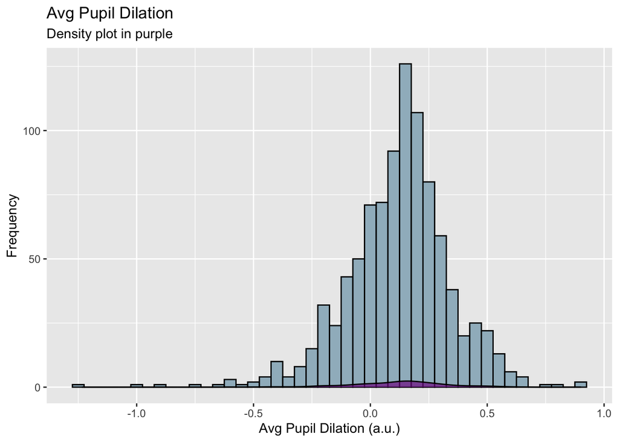

```r
# Plot histogram w/ density overlay
ggplot(pupilDat, aes(x = AvgPupilDilation)) +
  geom_histogram(binwidth = 0.05, color = "black", fill = "#A0B9C6") +
  geom_density(alpha = 0.7, fill = "#802392") +
  labs(
    title = "Avg Pupil Dilation",
    subtitle = "Density plot in purple",
    x = "Avg Pupil Dilation (a.u.)",
    y = "Frequency"
  )
```

```r
# Corr matrix for og data
originalDataCorr <- stats::cor(pupilDat %>% select_if(is.numeric), use = "complete.obs")
print(originalDataCorr)
```

```
##                         SNR   Quintile AvgPupilDilation
## SNR               1.0000000  0.0000000       -0.1734352
## Quintile          0.0000000  1.0000000       -0.0399076
## AvgPupilDilation -0.1734352 -0.0399076        1.0000000
```

### GAM Models

num of knots dictates flexibility of the smoothing function. Too few knots can underfit; too many can overfit.

num knots based on the complexity of the interaction and stats efficiency/computing power

```r
# for mod 1, regular GAM with no interactions
mod1_gam <- gam(AvgPupilDilation ~ s(SNR, k = 4) + s(Quintile, k = 5), data = pupilDat)
summary(mod1_gam)
```

```
##
## Family: gaussian
## Link function: identity
##
## Formula:
## AvgPupilDilation ~ s(SNR, k = 4) + s(Quintile, k = 5)
##
## Parametric coefficients:
##             Estimate Std. Error t value Pr(>|t|)
## (Intercept)  0.12017    0.00718   16.74   <2e-16 ***
## ---
## Signif. codes:  0 '***' 0.001 '**' 0.01 '*' 0.05 '.' 0.1 ' ' 1
##
## Approximate significance of smooth terms:
##               edf Ref.df      F  p-value
## s(SNR)      1.279  1.498 18.039 1.69e-06 ***
## s(Quintile) 2.421  2.922  1.958    0.139
## ---
## Signif. codes:  0 '***' 0.001 '**' 0.01 '*' 0.05 '.' 0.1 ' ' 1
##
## R-sq.(adj) =  0.0342   Deviance explained =  3.8%
## GCV = 0.0487  Scale est. = 0.048456  n = 940
```

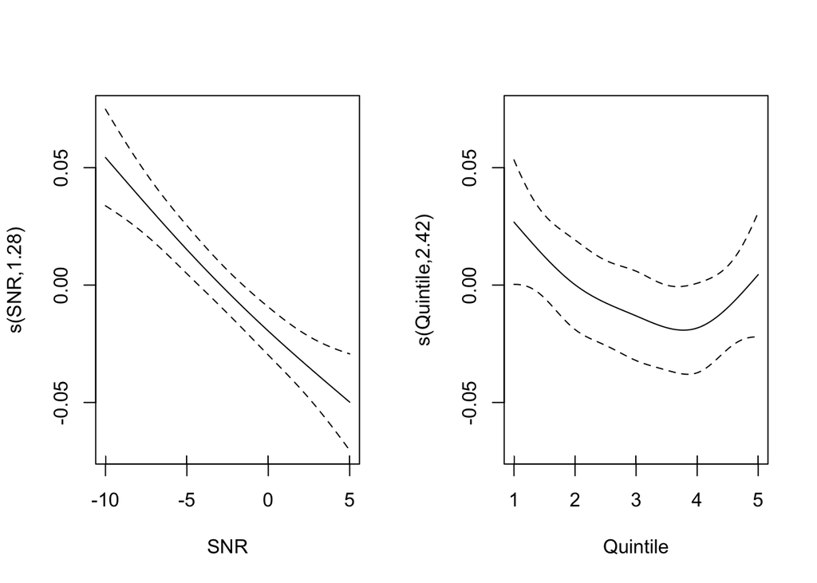

```r
plot(mod1_gam, pages = 1) # groupme
```

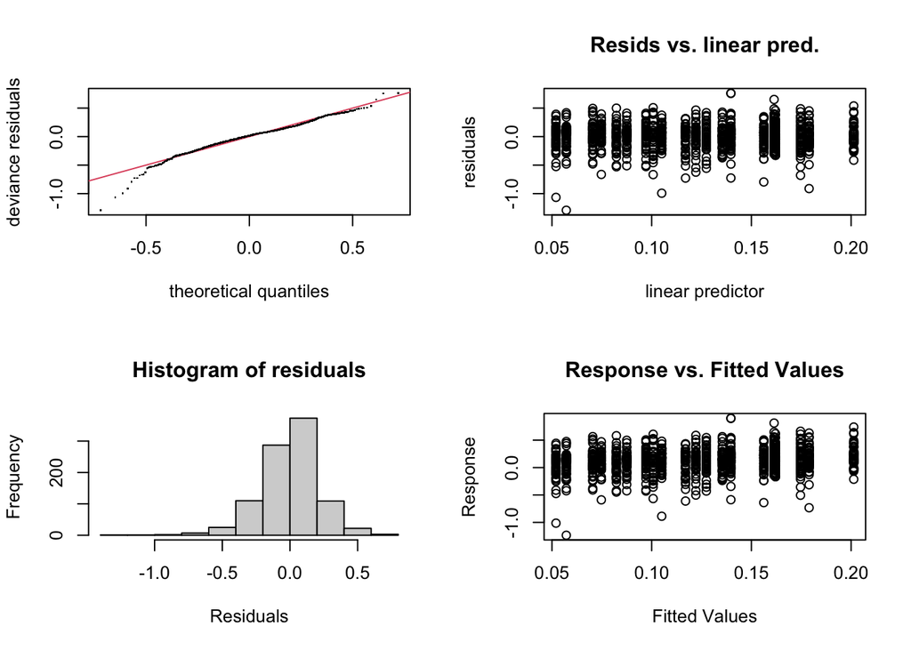

```
##
## Method: GCV   Optimizer: magic
## Smoothing parameter selection converged after 4 iterations.
## The RMS GCV score gradient at convergence was 3.070866e-07 .
## The Hessian was positive definite.
## Model rank =  8 / 8
##
## Basis dimension (k) checking results. Low p-value (k-index<1) may
## indicate that k is too low, especially if edf is close to k'.
##
##               k'  edf k-index p-value
## s(SNR)      3.00 1.28    0.59  <2e-16 ***
## s(Quintile) 4.00 2.42    0.64  <2e-16 ***
## ---
## Signif. codes:  0 '***' 0.001 '**' 0.01 '*' 0.05 '.' 0.1 ' ' 1
```

```r
gam.check(mod1_gam) # model diagnostic plots
```

### Mod2

```r
# mod 2; use tensor interaction of SNR & quintile
mod2_gam <- gam(AvgPupilDilation ~ te(SNR, Quintile, k = 4), data = pupilDat)
summary(mod2_gam)
```

```
##
## Family: gaussian
## Link function: identity
##
## Formula:
## AvgPupilDilation ~ te(SNR, Quintile, k = 4)
##
## Parametric coefficients:
##             Estimate Std. Error t value Pr(>|t|)
## (Intercept)  0.12017    0.00719   16.71   <2e-16 ***
## ---
## Signif. codes:  0 '***' 0.001 '**' 0.01 '*' 0.05 '.' 0.1 ' ' 1
##
## Approximate significance of smooth terms:
##                    edf Ref.df     F  p-value
## te(SNR,Quintile) 4.252  4.943 6.645 5.05e-06 ***
## ---
## Signif. codes:  0 '***' 0.001 '**' 0.01 '*' 0.05 '.' 0.1 ' ' 1
##
## R-sq.(adj) =  0.0315   Deviance explained = 3.59%
## GCV = 0.048862  Scale est. = 0.048589  n = 940
```

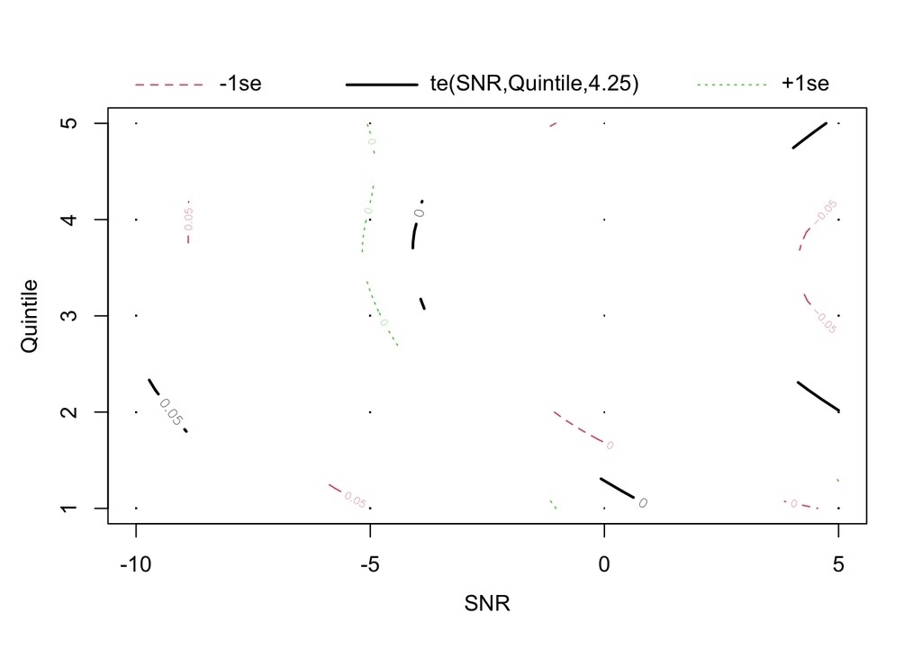

```r
plot(mod2_gam, pages = 1)
```

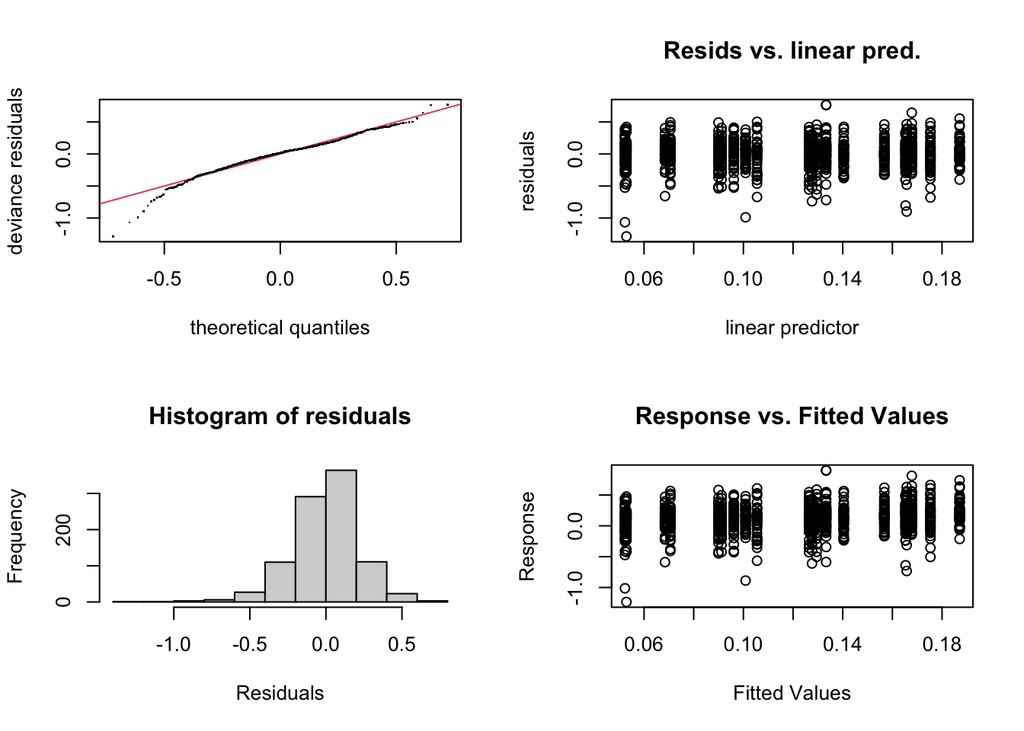

```
##
## Method: GCV   Optimizer: magic
## Smoothing parameter selection converged after 10 iterations.
## The RMS GCV score gradient at convergence was 2.444481e-07 .
## The Hessian was positive definite.
## Model rank =  16 / 16
##
## Basis dimension (k) checking results. Low p-value (k-index<1) may
## indicate that k is too low, especially if edf is close to k'.
##
##                     k'   edf k-index p-value
## te(SNR,Quintile) 15.00  4.25    0.97    0.23
```

```r
gam.check(mod2_gam)
```